# HW1, Part2

HG

22/05/2020

# **Homework-1 , Part-2**

# *QUESTION 1:*

Use the airbnb_data.csv provided and answer the following questions on Linear Regression:

## a) Fit a multiple linear regression model using price as the response variable and all others as predictor variables (Note: remove ‘id’ columns). Which variables are statistically significant in determining the price?

## b) Interpret the coefficients for predictors: room type(Shared Room), bedrooms?

## c) Predict the price (nearest dollar) for a listing with the following factors: bedrooms = 1, accommodates = 2, reviews = 70, overall_satisfaction = 4, and room_type= ‘Private room’.

## d) Identify outliers using Cook’s distance approach. Remove points having Cook’s distance > 1. Rerun the model after the removal of these points and print the summary.

```r
#a)

# data loading and keeping the required attributes only (removing the oned with "id" & the city name)
airbnb<-  data.frame(read.csv("airbnb_data.csv"))
airbnb <- airbnb[, 4:10]
airbnb <- airbnb[, -2]

View(head(airbnb))

airbnb_lm <- lm(formula = price ~ . , data = airbnb)
summary (airbnb_lm)
```

```
##
## Call:
## lm(formula = price ~ ., data = airbnb)
##
## Residuals:
##    Min     1Q Median     3Q    Max
## -367.8  -49.2    3.2   38.6 4032.7
##
## Coefficients:
##                        Estimate Std. Error t value Pr(>|t|)
## (Intercept)           -23.36172   21.88618  -1.067  0.28609
## room_typePrivate room  -0.93115   13.21827  -0.070  0.94386
## room_typeShared room  -76.66780   59.90939  -1.280  0.20099
## reviews                 0.01090    0.09982   0.109  0.91310
## overall_satisfaction  -10.48160    3.47320  -3.018  0.00262 **
## accommodates           23.00721    5.23952   4.391 1.27e-05 ***
## bedrooms               85.64533   11.45983   7.474 1.95e-13 ***
## ---
## Signif. codes:  0 '***' 0.001 '**' 0.01 '*' 0.05 '.' 0.1 ' ' 1
##
## Residual standard error: 167.1 on 847 degrees of freedom
## Multiple R-squared:  0.3228, Adjusted R-squared:  0.318
## F-statistic:  67.3 on 6 and 847 DF,  p-value: < 2.2e-16
```

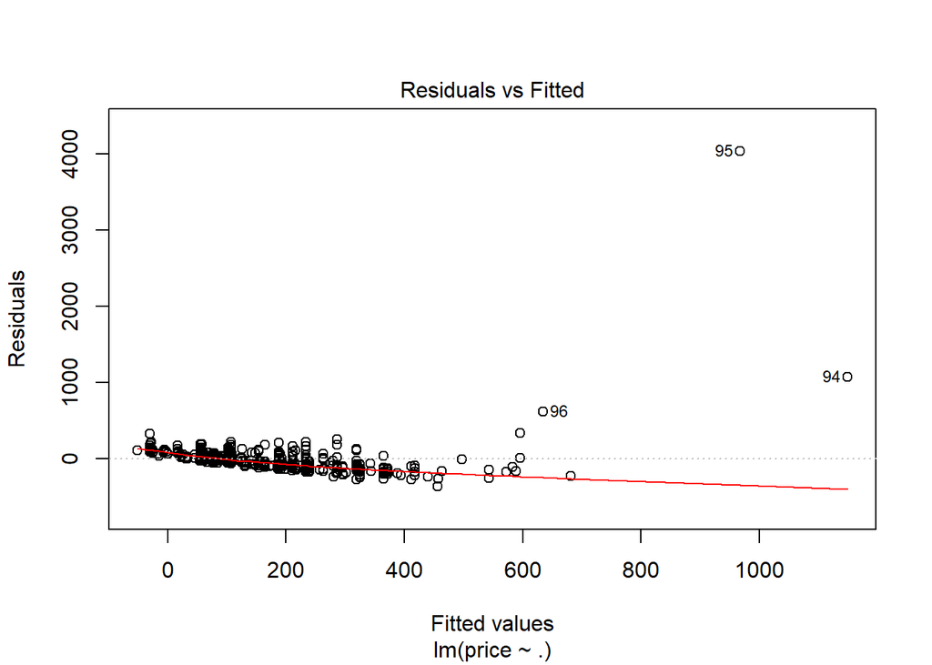

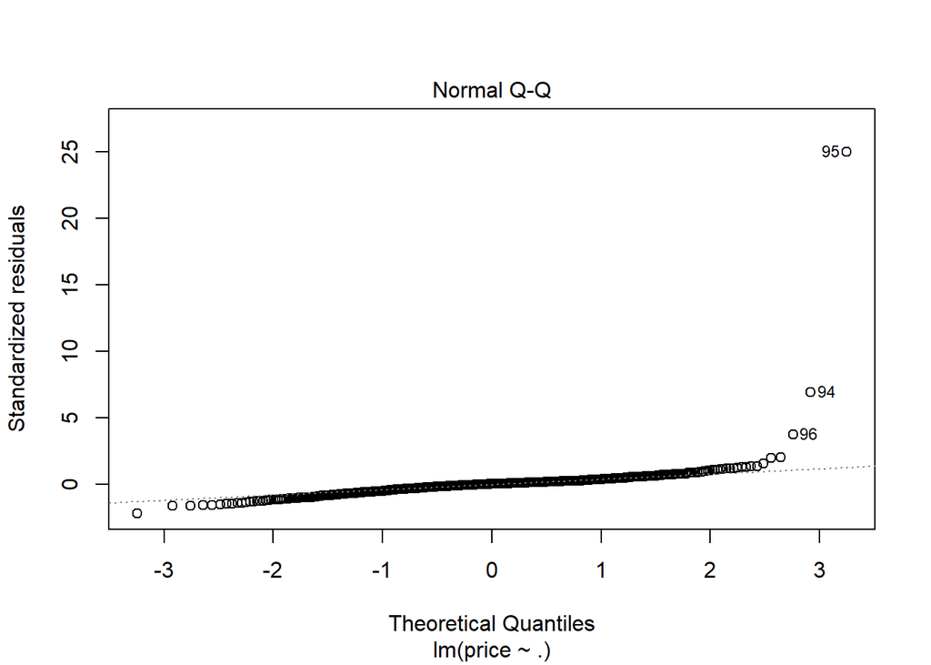

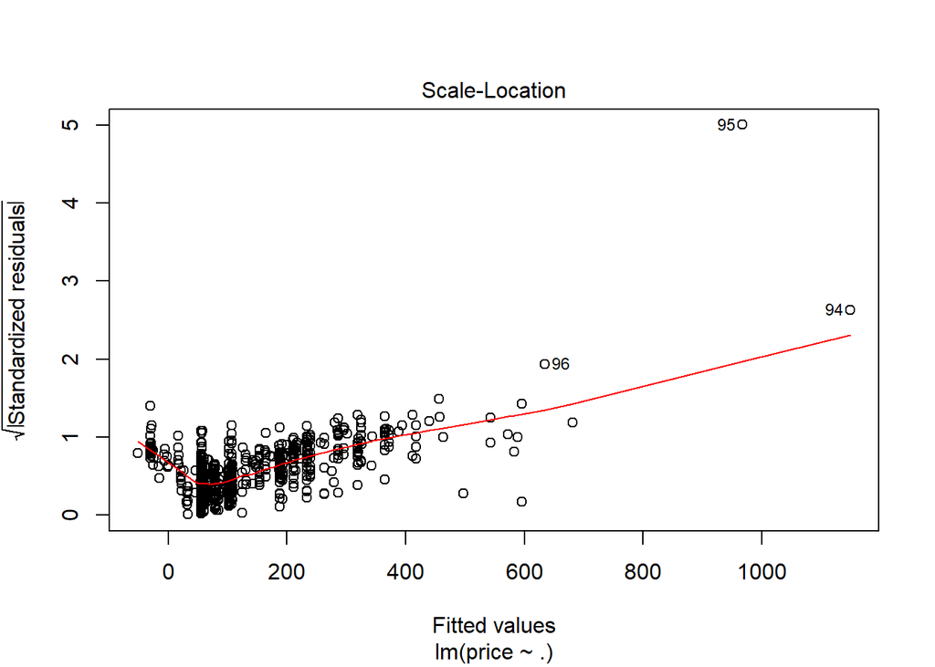

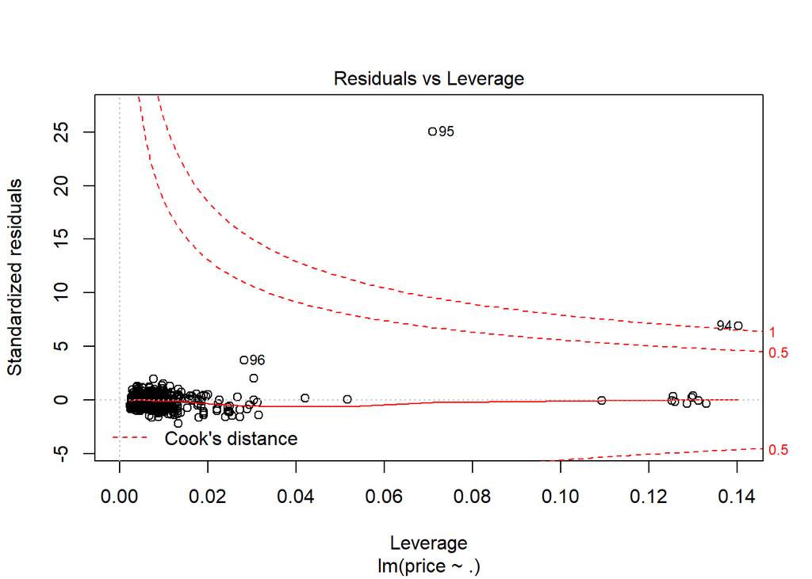

```r
plot(airbnb_lm)
```

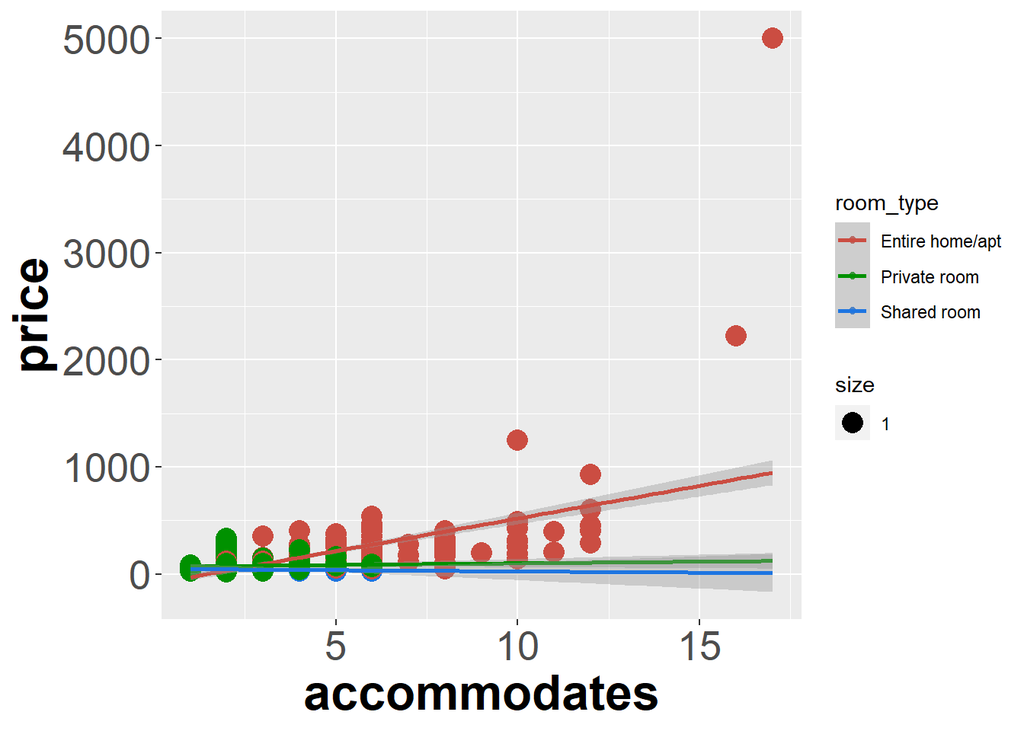

```r
ggplot(data = airbnb, aes(x = accommodates, y = price, colour=room_type)) + geom_point(aes(size=1)) +
scale_colour_hue(l=50) +
geom_smooth(method=lm,   # Add linear regression lines
           se=TRUE,    #  add shaded confidence region
           fullrange=TRUE) +
theme(axis.text.x = element_text(size=20), axis.text.y = element_text(size=20),
        axis.title=element_text(size=24,face="bold"))
```

## a) as per the model reported stats, the accomodates & bedrooms are the most significant for determining the price (highest coefficents & lowest p-values)

[figure not shown]

## b) Price = -23.36172 + (-0.93115) Private_Room + (-76.66780) Shared_Room + 0.0109 reviews + (-10.48160) overall_satisfaction + 23.0072 accomodates + 85.6453 bedrooms Interpret the coefficients for predictors: room type(Shared Room), bedrooms

coeffiecet for shared room : -76.66780 since it is a negative number it shows that if a room is shared one the starting price would be pretty low, starting price for a shared room = -23.36172 + (-76.6678);

coeffiecet for bedrooms : 85.6453 assuming other parameters are not changing, an incerease of one bedroom will incerease the pricing with rate of 85.6453$

```r
#c) Predict the price (nearest dollar) for a listing with the following factors: bedrooms = 1, accommodates = 2, reviews = 70, overall_satisfaction = 4, and room_type= 'Private room'
New_Point <- data.frame(bedrooms = 1, accommodates = 2, reviews = 70, overall_satisfaction = 4, room_type= 'Private room')
predict.price <- predict(airbnb_lm, New_Point)
predict.price
```

```
##        1
## 66.20316
```

## c)

Predicted Price = 66.20316$

```r
#d)Identify outliers using Cook's distance approach. Remove points having Cook's distance > 1. Rerun the model after the removal of these points and print the summary.
```

# d)

Identify outliers using Cook’s distance approach. Remove points having Cook’s distance > 1. Rerun the model after the removal of these points and print the summary.

from the earlier plots the points 94, 95 & 96 looks to be differnt and maybe can be considered as outliers. Using the crtiteria “Cook’s distance >1” the point 94 & 95 looks to be an outlier and was removed:

```r
#removing the influentials/outliers:

cooksd <- cooks.distance(airbnb_lm)

influential <- as.numeric(names(cooksd)[cooksd > 1])

influential
```

```
## [1] 94 95
```

```r
airbnb_no_influential <- airbnb [-influential,]

#build a new model after removing the influnetion points

airbnb_no_IP_lm <- lm(formula = price ~ . , data = airbnb_no_influential)
summary (airbnb_no_IP_lm)
```

```
##
## Call:
## lm(formula = price ~ ., data = airbnb_no_influential)
##
## Residuals:
##     Min      1Q  Median      3Q     Max
## -190.95  -32.43   -7.09   20.35  876.26
##
## Coefficients:
##                        Estimate Std. Error t value Pr(>|t|)
## (Intercept)            75.01310    9.09152   8.251 6.01e-16 ***
## room_typePrivate room -32.28201    5.38034  -6.000 2.92e-09 ***
## room_typeShared room  -91.69951   24.28958  -3.775 0.000171 ***
## reviews                -0.05915    0.04047  -1.462 0.144202
## overall_satisfaction   -6.78957    1.41118  -4.811 1.78e-06 ***
## accommodates           11.90698    2.14267   5.557 3.68e-08 ***
## bedrooms               35.93177    4.87968   7.364 4.25e-13 ***
## ---
## Signif. codes:  0 '***' 0.001 '**' 0.01 '*' 0.05 '.' 0.1 ' ' 1
##
## Residual standard error: 67.73 on 845 degrees of freedom
## Multiple R-squared:  0.4249, Adjusted R-squared:  0.4208
## F-statistic:   104 on 6 and 845 DF,  p-value: < 2.2e-16
```

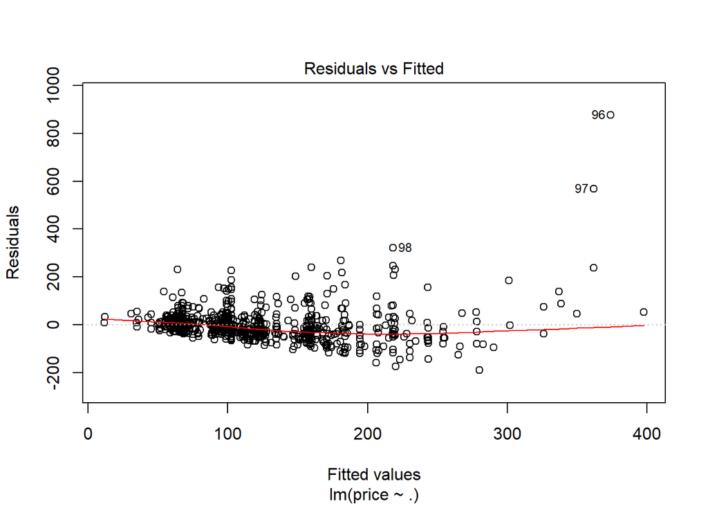

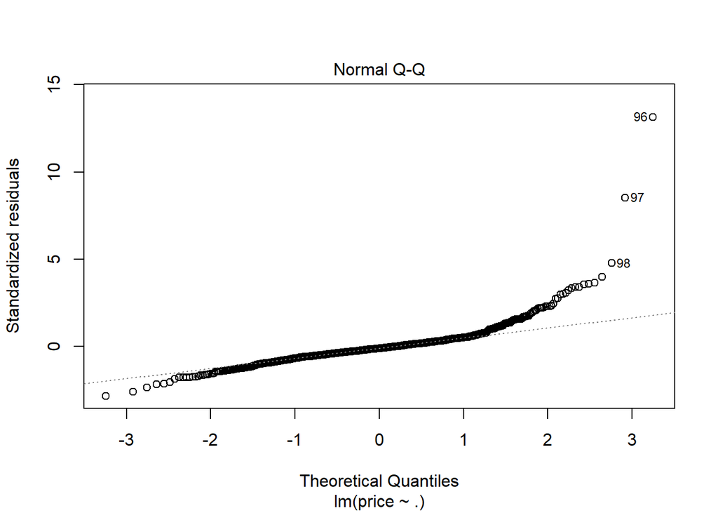

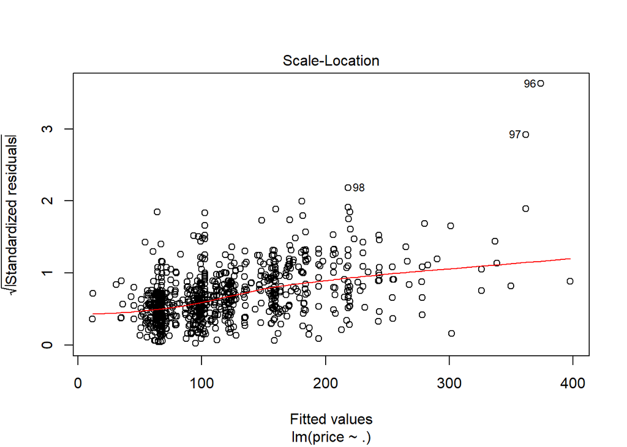

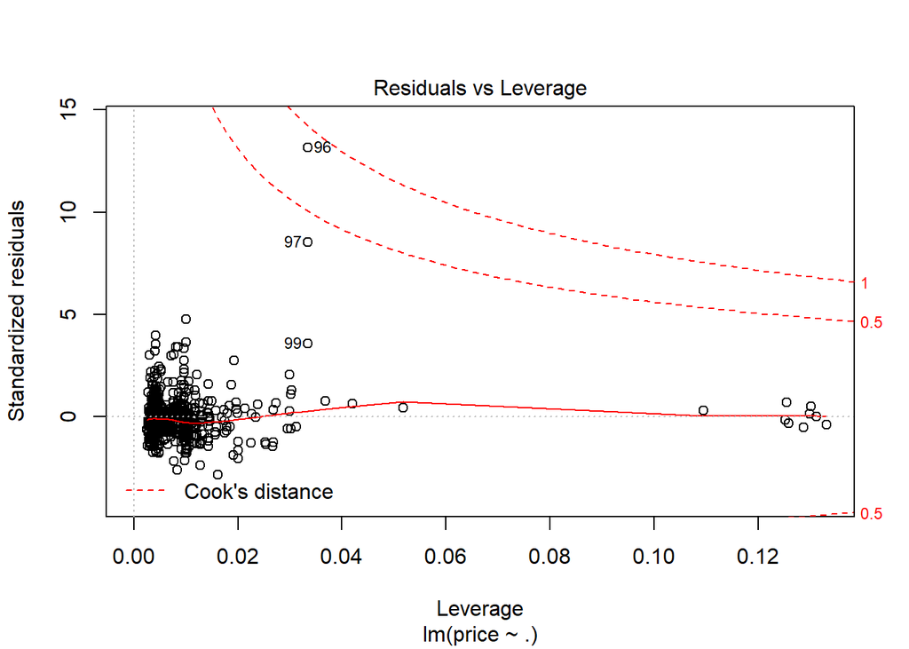

```r
plot(airbnb_no_IP_lm)
```

```r
#build a new model after removing the influnetion points & outliers
outliers <- append (influential,96)
outliers
```

```
## [1] 94 95 96
```

```r
airbnb_no_outliers <- airbnb [-outliers,]
airbnb_no_OP_lm <- lm(formula = price ~ . , data = airbnb_no_outliers)
summary (airbnb_no_OP_lm)
```

```
##
## Call:
## lm(formula = price ~ ., data = airbnb_no_outliers)
##
## Residuals:
##     Min      1Q  Median      3Q     Max
## -172.68  -30.02   -7.69   19.29  591.40
##
## Coefficients:
##                        Estimate Std. Error t value Pr(>|t|)
## (Intercept)            78.24738    8.11456   9.643  < 2e-16 ***
## room_typePrivate room -33.28108    4.80090  -6.932 8.23e-12 ***
## room_typeShared room  -93.33511   21.67183  -4.307 1.85e-05 ***
## reviews                -0.06669    0.03611  -1.847   0.0651 .
## overall_satisfaction   -5.51510    1.26204  -4.370 1.40e-05 ***
## accommodates           12.03995    1.91174   6.298 4.85e-10 ***
## bedrooms               28.96750    4.37926   6.615 6.60e-11 ***
## ---
## Signif. codes:  0 '***' 0.001 '**' 0.01 '*' 0.05 '.' 0.1 ' ' 1
##
## Residual standard error: 60.43 on 844 degrees of freedom
## Multiple R-squared:  0.4353, Adjusted R-squared:  0.4313
## F-statistic: 108.4 on 6 and 844 DF,  p-value: < 2.2e-16
```

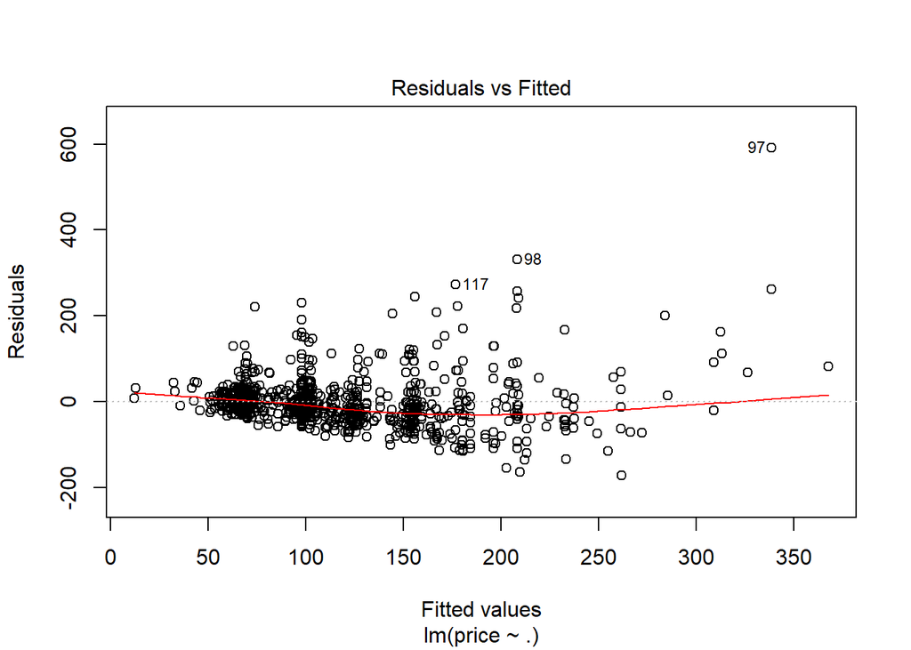

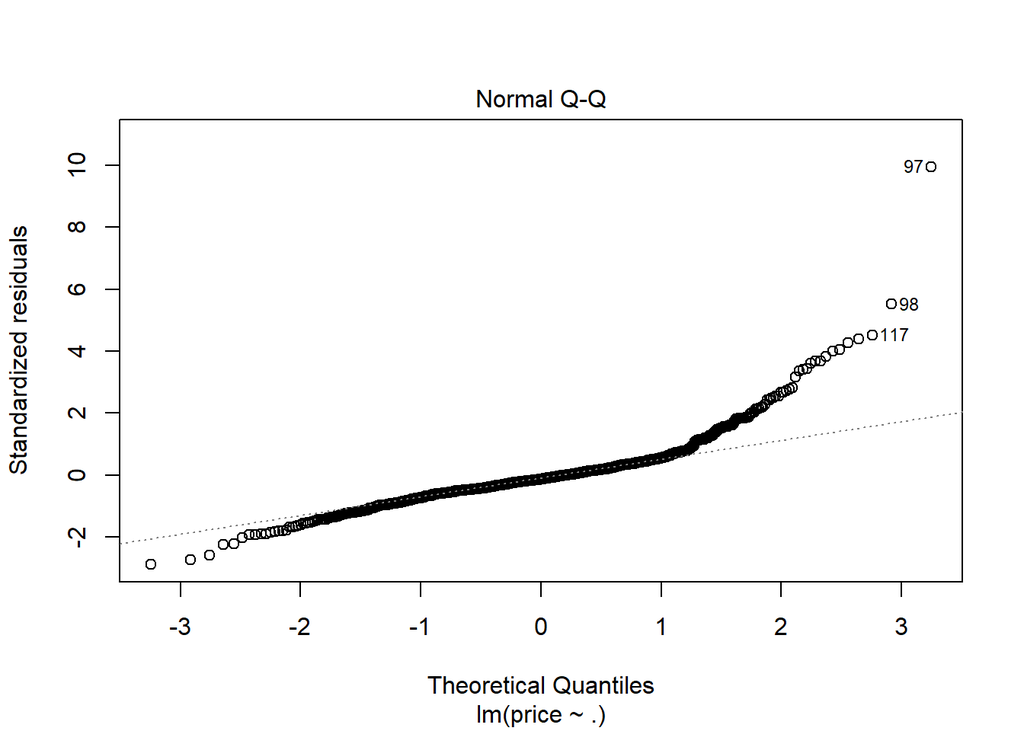

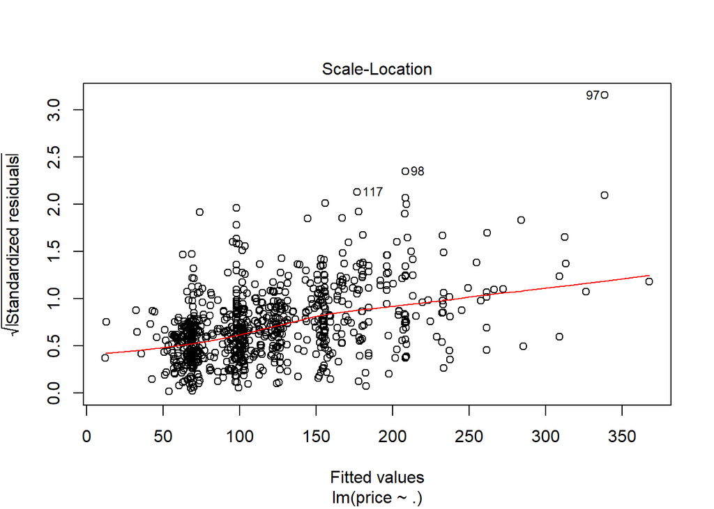

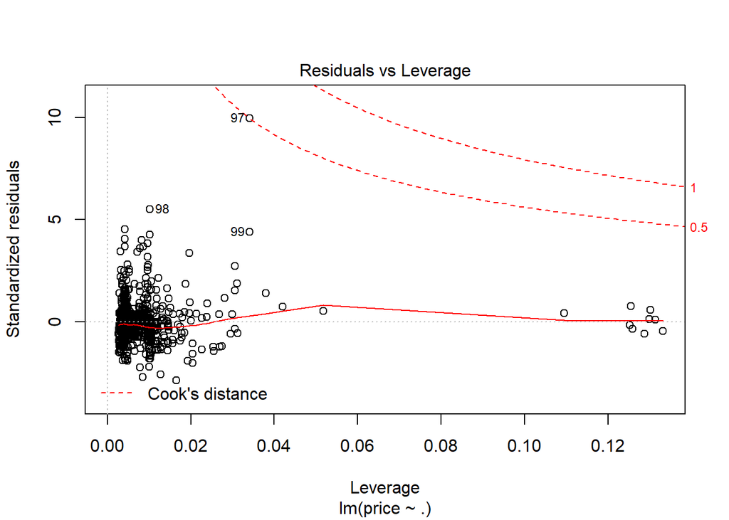

```r
plot(airbnb_no_OP_lm)
```

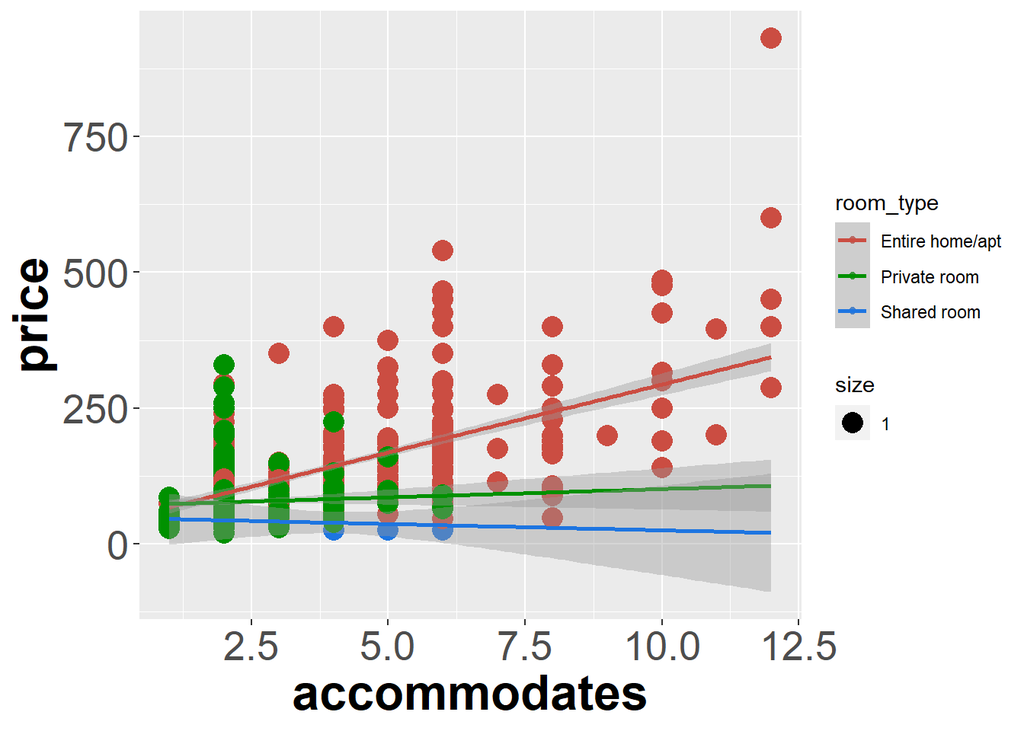

```r
ggplot(data = airbnb_no_outliers, aes(x = accommodates, y = price, colour=room_type)) + geom_point(aes(size=1)) +
scale_colour_hue(l=50) +
geom_smooth(method=lm,   # Add linear regression lines
           se=TRUE,    #  add shaded confidence region
           fullrange=TRUE) +
theme(axis.text.x = element_text(size=20), axis.text.y = element_text(size=20),
        axis.title=element_text(size=24,face="bold"))
```

in addition to the influential points, 94 & 95, I also tested removing another value 96, as I think that value is probably an ouutlier too

```r
#this is for Question#2 preperation, selecting the points with overall_satisfaction != 0.0
airbnb_no_outliers_Zero_satisfaction <- filter(airbnb_no_outliers, overall_satisfaction > 0.5)
```

the updated plot suggest that price for the room types pivate and shared are kind of constant, that make sence as the majority if these type rooms has one bed room only, and other attributes has little influenece on ther prising of these room type; on the other hand pricing fro the room type as entire home varies as per number of bedroom and number of accomdates.

# *QUESTION 2:*

Use the direct_marketing.csv provided and answer the following questions on Linear Regression: Create indicator variables for the ‘History’ column. Considering the base case as None (i.e., create Low, Medium and High variables with 1 denoting the positive case and 0 the negative) and few additional variables LowSalary, MediumSalary and HighSalary based on the customer history type i.e., MediumSalary = Medium*Salary etc.

## a) Fit a multiple linear regression model using AmountSpent as the response variable and the indicator variables along with their salary variables as the predictors

## b) What is the amount spent by a customer for each historic type provided his/her salary is $10,000 based on the model constructed in part a?

Use the airbnb_data.csv provided and answer the following questions on Linear Regression: Perform Log transformation for the variables price and overall_satisfaction, make necessary transformations suggested in the class.

## c) Fit all four models i.e., linear-linear, linear-log, log-linear, and log-log regression models using price as the response variable and overall_satisfaction as the predictor.

## d) Which of the four models has the best R2? Do you have any comments on the choice of the dependent variable?

```r
#a)

# data loading
direct_marketing <-  data.frame(read.csv("direct_marketing.csv"))
#View(head(direct_marketing))

#creating indicator variables for the History
direct_marketing<- direct_marketing %>%
  mutate(Low_History = ifelse(History=="Low",1,0)) %>%
  mutate(Medium_History = ifelse(History=="Medium",1,0)) %>%
  mutate(High_History = ifelse(History=="High",1,0)) %>%
  mutate(LowHistory_Salary = Low_History * Salary) %>%
  mutate(MediumHistory_Salary = Medium_History * Salary) %>%
  mutate(HighHistory_Salary = High_History * Salary)
#creating linear model
direct_marketing_lm <- lm(formula = AmountSpent ~ Salary + Low_History + Medium_History + High_History + LowHistory_Salary + MediumHistory_Salary + HighHistory_Salary , data = direct_marketing)


summary (direct_marketing_lm)
```

```
##
## Call:
## lm(formula = AmountSpent ~ Salary + Low_History + Medium_History +
##     High_History + LowHistory_Salary + MediumHistory_Salary +
##     HighHistory_Salary, data = direct_marketing)
##
## Residuals:
##     Min      1Q  Median      3Q     Max
## -214.33  -25.47   -6.46   20.64  352.50
##
## Coefficients:
##                        Estimate Std. Error t value Pr(>|t|)
## (Intercept)           1.9622199  6.3880253   0.307 0.758777
## Salary                0.0023641  0.0001071  22.083  < 2e-16 ***
## Low_History          25.4466733  8.9203292   2.853 0.004426 **
## Medium_History       79.2984388 12.8982169   6.148 1.14e-09 ***
## High_History         72.6735221 15.2270169   4.773 2.09e-06 ***
## LowHistory_Salary    -0.0021069  0.0001890 -11.150  < 2e-16 ***
## MediumHistory_Salary -0.0021153  0.0002182  -9.693  < 2e-16 ***
## HighHistory_Salary   -0.0006408  0.0001926  -3.328 0.000908 ***
## ---
## Signif. codes:  0 '***' 0.001 '**' 0.01 '*' 0.05 '.' 0.1 ' ' 1
##
## Residual standard error: 55.79 on 992 degrees of freedom
## Multiple R-squared:  0.6654, Adjusted R-squared:  0.6631
## F-statistic: 281.9 on 7 and 992 DF,  p-value: < 2.2e-16
```

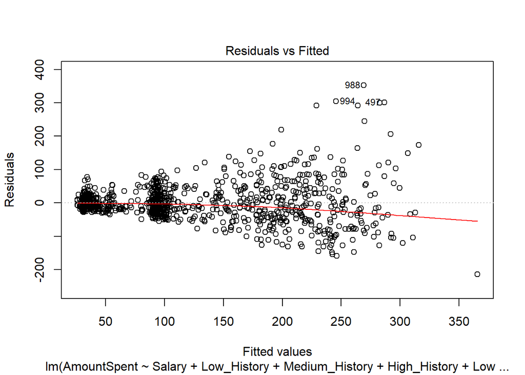

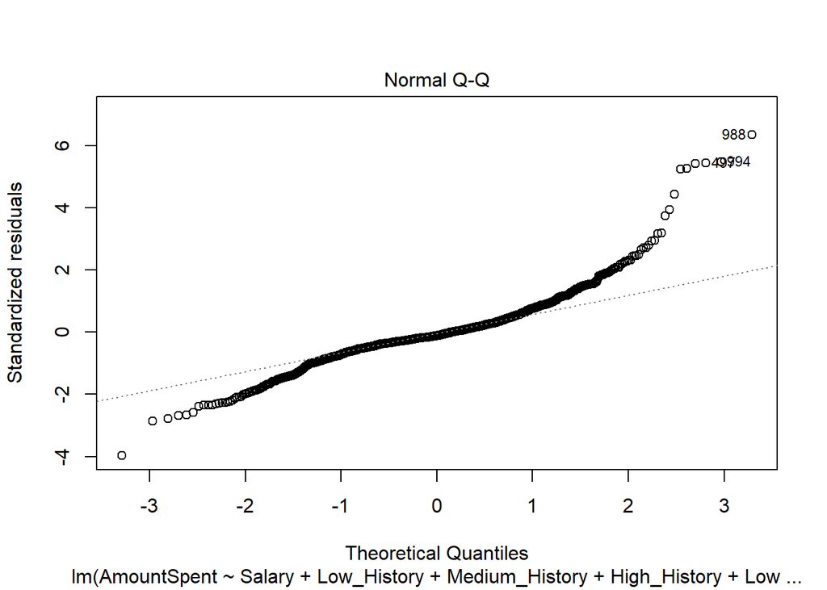

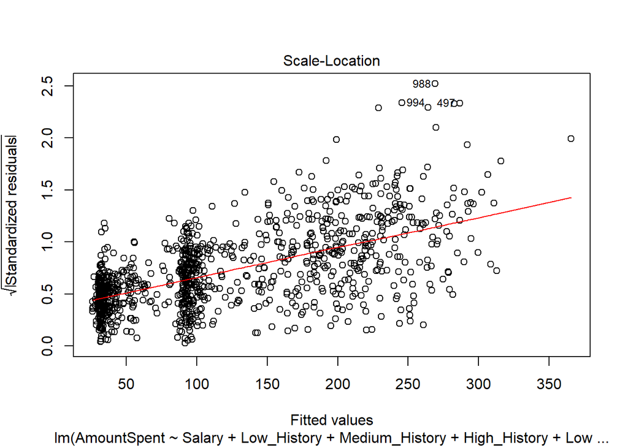

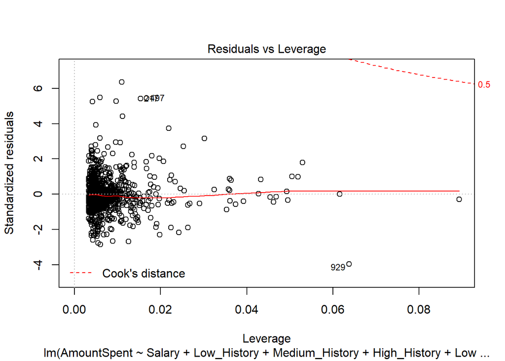

```r
plot(direct_marketing_lm)
```

# b)

AmountSpent = 1.9622199 + 0.0023641 Salary + 25.4466733 Low_History + 79.2984388 Medium_History + 72.6735221 High_History + (-0.0021069) LowHistory_Salary + (-0.0021153) MediumHistory_Salary + (-0.0006408) HighHistory_Salary What is the amount spent by a customer for each historic type provided his/her salary is $10,000 based on the model constructed in part a?

```r
Low_History_Salary_1000<- data.frame(Salary = 10000, Low_History = 1, Medium_History = 0, High_History = 0, LowHistory_Salary=10000 , MediumHistory_Salary=0 , HighHistory_Salary=0 )
predict.AmountSpent.Low_History_Salary_1000 <- predict(direct_marketing_lm, Low_History_Salary_1000)
predict.AmountSpent.Low_History_Salary_1000
```

```
##        1
## 29.98157
```

```r
Medium_History_Salary_1000<- data.frame(Salary = 10000, Low_History = 0, Medium_History = 1, High_History = 0, LowHistory_Salary=0 , MediumHistory_Salary=10000 , HighHistory_Salary=0 )
predict.AmountSpent.Medium_History_Salary_1000 <- predict(direct_marketing_lm, Medium_History_Salary_1000)
predict.AmountSpent.Medium_History_Salary_1000
```

```
##        1
## 83.74909
```

```r
High_History_Salary_1000<- data.frame(Salary = 10000, Low_History = 0, Medium_History = 0, High_History = 1, LowHistory_Salary=0 , MediumHistory_Salary=0 , HighHistory_Salary=10000 )
predict.AmountSpent.High_History_Salary_1000 <- predict(direct_marketing_lm, High_History_Salary_1000)
predict.AmountSpent.High_History_Salary_1000
```

```
##        1
## 91.86874
```

```r
Null_History_Salary_1000<- data.frame(Salary = 10000, Low_History = 0, Medium_History = 0, High_History = 0, LowHistory_Salary=0 , MediumHistory_Salary=0 , HighHistory_Salary=0 )
predict.AmountSpent.Null_History_Salary_1000 <- predict(direct_marketing_lm, Null_History_Salary_1000)
predict.AmountSpent.Null_History_Salary_1000
```

```
##        1
## 25.60347
```

Apmount Spent Low History with 10000 Salary = 29.98157 Apmount Spent Medium History with 10000 Salary = 83.74909 Apmount Spent High History with 10000 Salary = 91.86874 Apmount Spent Null History with 10000 Salary = 25.60347

# log transformation

```r
#c & d)
# removing the points with overall_satisfaction = 0.0
#airbnb_no_outliers_Zero_satisfaction <- filter(airbnb_no_outliers, overall_satisfaction > 0.5)

# Fit all four models i.e., linear-linear, linear-log, log-linear, and log-log regression models using price as the response variable and overall_satisfaction as the predictor

airbnb_no_outliers_Zero_satisfaction <- airbnb_no_outliers_Zero_satisfaction %>%
  mutate(Ln_price = log(price)) %>%
  mutate(Ln_overall_satisfaction = log(overall_satisfaction))

# Model A:  price = b0 + b1*overall_satisfaction  Linear-linear model

Lin_Lin <- lm(formula = price ~ overall_satisfaction , data = airbnb_no_outliers_Zero_satisfaction)
summary(Lin_Lin)
```

```
##
## Call:
## lm(formula = price ~ overall_satisfaction, data = airbnb_no_outliers_Zero_satisfaction)
##
## Residuals:
##    Min     1Q Median     3Q    Max
## -84.89 -38.89 -18.89  20.26 371.11
##
## Coefficients:
##                      Estimate Std. Error t value Pr(>|t|)
## (Intercept)            -27.55      59.47  -0.463   0.6433
## overall_satisfaction    28.29      12.10   2.338   0.0197 *
## ---
## Signif. codes:  0 '***' 0.001 '**' 0.01 '*' 0.05 '.' 0.1 ' ' 1
##
## Residual standard error: 67.21 on 724 degrees of freedom
## Multiple R-squared:  0.00749,    Adjusted R-squared:  0.006119
## F-statistic: 5.464 on 1 and 724 DF,  p-value: 0.01968
```

```r
# Model B:  price = b0 + b1*log(overall_satisfaction)  Linear-Log Model

Lin_LN <- lm(formula = price ~ Ln_overall_satisfaction , data = airbnb_no_outliers_Zero_satisfaction)
summary(Lin_LN)
```

```
##
## Call:
## lm(formula = price ~ Ln_overall_satisfaction, data = airbnb_no_outliers_Zero_satisfaction)
##
## Residuals:
##    Min     1Q Median     3Q    Max
## -84.85 -38.85 -18.85  20.15 371.15
##
## Coefficients:
##                         Estimate Std. Error t value Pr(>|t|)
## (Intercept)               -97.68      90.09  -1.084   0.2786
## Ln_overall_satisfaction   131.43      56.63   2.321   0.0206 *
## ---
## Signif. codes:  0 '***' 0.001 '**' 0.01 '*' 0.05 '.' 0.1 ' ' 1
##
## Residual standard error: 67.21 on 724 degrees of freedom
## Multiple R-squared:  0.007386,   Adjusted R-squared:  0.006015
## F-statistic: 5.387 on 1 and 724 DF,  p-value: 0.02056
```

```r
# Model C:  log(price) = b0 + b1*overall_satisfaction  Log-Linear Model

LN_Lin <- lm(formula = Ln_price ~ overall_satisfaction , data = airbnb_no_outliers_Zero_satisfaction)
summary(LN_Lin)
```

```
##
## Call:
## lm(formula = Ln_price ~ overall_satisfaction, data = airbnb_no_outliers_Zero_satisfaction)
##
## Residuals:
##      Min       1Q   Median       3Q      Max
## -1.46483 -0.28618 -0.04257  0.30883  1.59152
##
## Coefficients:
##                      Estimate Std. Error t value Pr(>|t|)
## (Intercept)           3.23760    0.45451   7.123 2.55e-12 ***
## overall_satisfaction  0.27177    0.09249   2.938   0.0034 **
## ---
## Signif. codes:  0 '***' 0.001 '**' 0.01 '*' 0.05 '.' 0.1 ' ' 1
##
## Residual standard error: 0.5136 on 724 degrees of freedom
## Multiple R-squared:  0.01178,    Adjusted R-squared:  0.01042
## F-statistic: 8.634 on 1 and 724 DF,  p-value: 0.003405
```

```r
# Model D:  log(price) = b0 + b1*log(overall_satisfaction)  Log-Log Model

LN_LN <- lm(formula = Ln_price ~ Ln_overall_satisfaction , data = airbnb_no_outliers_Zero_satisfaction)
summary(LN_LN)
```

```
##
## Call:
## lm(formula = Ln_price ~ Ln_overall_satisfaction, data = airbnb_no_outliers_Zero_satisfaction)
##
## Residuals:
##      Min       1Q   Median       3Q      Max
## -1.46735 -0.28870 -0.04223  0.30917  1.58900
##
## Coefficients:
##                         Estimate Std. Error t value Pr(>|t|)
## (Intercept)               2.5641     0.6885   3.724 0.000211 ***
## Ln_overall_satisfaction   1.2625     0.4328   2.917 0.003641 **
## ---
## Signif. codes:  0 '***' 0.001 '**' 0.01 '*' 0.05 '.' 0.1 ' ' 1
##
## Residual standard error: 0.5137 on 724 degrees of freedom
## Multiple R-squared:  0.01162,    Adjusted R-squared:  0.01025
## F-statistic:  8.51 on 1 and 724 DF,  p-value: 0.003641
```

##) d reported R2:

Lin-Lin R-squared: 0.00749

Lin-Ln R-squared: 0.007386

Ln-Lin R-squared: 0.01178

Ln-Ln R-squared: 0.01162

The overall R2 values are very low, vindicating there might be only a very weak relation between price & overall satisfaction. considering Ln (Price) has slightly increased R2 value. the Ln-Lin model reported the highest R2.

# **Question 3**

The attached titanic_data.csv; It has been cleaned to remove all rows which contain missing values. We will perform logistic regression on this cleaned dataset.

The dataset contains the following columns: ‘Name’ - Passenger Name - factor ‘PClass’ - Passenger Class (1st, 2nd, 3rd) - factor ‘Age’ - Passenger Age - number ‘Sex’ - Passenger Sex – female, male ‘Survived’ – 1 if passenger survived, 0 if not - number

After converting the survived variable to be a factor with two levels, 0 and 1, perform logistic regression on the dataset using ‘survived’ as the response and ‘Sex’ as the explanatory variable.

## a) Display the model summary.

## b) What does the value of the intercept coefficient represent in this model?

## c) Determine the probability of survival for females.

## d) Determine the probability of survival for males.

```r
# data loading
titanic <-  data.frame(read.csv("titanic_data.csv"))

View(head(titanic))

# converting the survived variable to be a factor with two levels
titanic$Survived <- factor(titanic$Survived)

titanic<- titanic %>%
  mutate(Sex_female = ifelse(Sex=="female",1,0)) %>%
  mutate(Sex_male = ifelse(Sex=="male",1,0))

#buidling the logistic regression:
titanic_logit <- glm(Survived ~ Sex_female , data = titanic, family = "binomial")
#a)
summary(titanic_logit)
```

```
##
## Call:
## glm(formula = Survived ~ Sex_female, family = "binomial", data = titanic)
##
## Deviance Residuals:
##     Min       1Q   Median       3Q      Max
## -1.6735  -0.6776  -0.6776   0.7524   1.7800
##
## Coefficients:
##             Estimate Std. Error z value Pr(>|z|)
## (Intercept)  -1.3545     0.1145  -11.83   <2e-16 ***
## Sex_female    2.4718     0.1783   13.86   <2e-16 ***
## ---
## Signif. codes:  0 '***' 0.001 '**' 0.01 '*' 0.05 '.' 0.1 ' ' 1
##
## (Dispersion parameter for binomial family taken to be 1)
##
##     Null deviance: 1025.57  on 755  degrees of freedom
## Residual deviance:  796.64  on 754  degrees of freedom
## AIC: 800.64
##
## Number of Fisher Scoring iterations: 4
```

```r
#b) intercept interpretation:
```

2. Since the intercept is negative the survival Odds for males is low, the intercept is natual log of survival odds, and not the odds, for male

```r
# c & d) reported surviving probabilities for male & female:


# to calculate the survial probability for male and female the following function can be useful:

logit2prob <- function(logit){
  odds <- exp(logit)
  prob <- odds / (1 + odds)
  return(prob)
}

# we then use the coefficients of the logit model to caculate the Ln of odds and then feed them into the probability calculation function to report the survival probabilities

ln_SurvivalOdds_Male_and_Female <- c(as.numeric(coef(titanic_logit)[1]), as.numeric( coef(titanic_logit)[1] + coef(titanic_logit)[2]))
print("Survival probability for males and females: ")
```

```
## [1] "Survival probability for males and females: "
```

```r
logit2prob(ln_SurvivalOdds_Male_and_Female)
```

```
## [1] 0.2051282 0.7534722
```

```r
#however the prdict function does all the above much easier
print("Survival probability for males: ")
```

```
## [1] "Survival probability for males: "
```

```r
predict(titanic_logit, data.frame(Sex_female=0)  , type="response")
```

```
##         1
## 0.2051282
```

```r
print("Survival probability for females: ")
```

```
## [1] "Survival probability for females: "
```

```r
predict(titanic_logit, data.frame(Sex_female=1)  , type="response")
```

```
##         1
## 0.7534722
```

c & d) female surviving probability: 0.753 (~ 0.8) male surviving probabaility: 0.205 (~ 0.2)